# Traffic and Drug Related Violations Analyzation

Overview: Analyze traffic stop data to identify patterns and insights related to driver demographics, violations, and drugs-related stops. Use Python's data manipulation and visualization libraries for effective analysis and presentation.

## Part 1: Data Understanding and Cleaning

#### 1. Understand the Dataset: Traffic and Drug Related Violations

```python
import pandas as pd
import matplotlib.pyplot as plt
import seaborn as sns
#In order to input a csv file, we use pandas & we use matplotlib so we can create visualizations for this dataset for further analysis
```

```python
# Read the CSV file into a pandas DataFrame
df = pd.read_csv("3_traffic_violaions.csv")
```

```python
# display the first 10 rows to ensure the csv file copied correctly into the notebook
print(df.head(10))
```

```
   stop_date stop_time  country_name driver_gender  driver_age_raw  \
0   1/2/2005      1:55           NaN             M          1985.0
1  1/18/2005      8:15           NaN             M          1965.0
2  1/23/2005     23:15           NaN             M          1972.0
3  2/20/2005     17:15           NaN             M          1986.0
4  3/14/2005     10:00           NaN             F          1984.0
5  3/23/2005      9:45           NaN             M          1982.0
6   4/1/2005     17:30           NaN             M          1969.0
7   6/6/2005     13:20           NaN             F          1986.0
8  7/13/2005     10:15           NaN             M          1970.0
9  7/13/2005     15:45           NaN             M          1970.0

   driver_age driver_race                   violation_raw  violation  \
0        20.0       White                        Speeding   Speeding
1        40.0       White                        Speeding   Speeding
```

[output cut: 32 more lines]

```python
#copy data frame into a new data frame for analysis
df_new = df.copy()
```

```python
#check for null values
print("Null Values per Column:")
print(df_new.isnull().sum())
```

```
Null Values per Column:
stop_date                 0
stop_time                 1
country_name          52966
driver_gender          3386
driver_age_raw         3378
driver_age             3620
driver_race            3385
violation_raw          3385
violation              3385
search_conducted          1
search_type           50881
stop_outcome           3385
is_arrested            3385
stop_duration          3385
drugs_related_stop        1
dtype: int64
```

```python
#structure of data
print("Dataset Structure:")
print(df_new.info())
```

```
Dataset Structure:
<class 'pandas.core.frame.DataFrame'>
RangeIndex: 52966 entries, 0 to 52965
Data columns (total 15 columns):
 #   Column              Non-Null Count  Dtype
---  ------              --------------  -----
 0   stop_date           52966 non-null  object
 1   stop_time           52965 non-null  object
 2   country_name        0 non-null      float64
 3   driver_gender       49580 non-null  object
 4   driver_age_raw      49588 non-null  float64
 5   driver_age          49346 non-null  float64
 6   driver_race         49581 non-null  object
 7   violation_raw       49581 non-null  object
 8   violation           49581 non-null  object
 9   search_conducted    52965 non-null  object
 10  search_type         2085 non-null   object
 11  stop_outcome        49581 non-null  object
 12  is_arrested         49581 non-null  object
 13  stop_duration       49581 non-null  object
 14  drugs_related_stop  52965 non-null  object
dtypes: float64(3), object(12)
memory usage: 6.1+ MB
None
```

```python
#specific data structures for each column
print("Specific data structure for each column")
for column in df_new.columns:
    unique_vals = df_new[column].nunique()
    print(f"{column}: {unique_vals} unique values")
```

```
Specific data structure for each column
stop_date: 2223 unique values
stop_time: 1427 unique values
country_name: 0 unique values
driver_gender: 2 unique values
driver_age_raw: 91 unique values
driver_age: 72 unique values
driver_race: 5 unique values
violation_raw: 11 unique values
violation: 5 unique values
search_conducted: 2 unique values
search_type: 23 unique values
stop_outcome: 6 unique values
is_arrested: 2 unique values
stop_duration: 3 unique values
drugs_related_stop: 2 unique values
```

```python
#display specific stats for this dataset
print("Descriptive Statistics:")
print(df_new.describe(include='all'))
```

```
Descriptive Statistics:
        stop_date stop_time  country_name driver_gender  driver_age_raw  \
count       52966     52965           0.0         49580    49588.000000
unique       2223      1427           NaN             2             NaN
top     5/16/2007     11:00           NaN             M             NaN
freq           62       256           NaN         36564             NaN
mean          NaN       NaN           NaN           NaN     1965.712229
std           NaN       NaN           NaN           NaN      132.195712
min           NaN       NaN           NaN           NaN        0.000000
25%           NaN       NaN           NaN           NaN     1965.000000
50%           NaN       NaN           NaN           NaN     1977.000000
75%           NaN       NaN           NaN           NaN     1985.000000
max           NaN       NaN           NaN           NaN     8801.000000

          driver_age driver_race violation_raw violation search_conducted  \
count   49346.000000       49581         49581     49581            52965
unique           NaN           5            11         5                2
top              NaN       White      Speeding  Speeding            False
freq             NaN       37364         32139     32139            50880
mean       34.171483         NaN           NaN       NaN              NaN
std        12.769907         NaN           NaN       NaN              NaN
min        15.000000         NaN           NaN       NaN              NaN
25%        23.000000         NaN           NaN       NaN              NaN
50%        31.000000         NaN           NaN       NaN              NaN
75%        43.000000         NaN           NaN       NaN              NaN
max        88.000000         NaN           NaN       NaN              NaN

               search_type stop_outcome is_arrested stop_duration  \
count                 2085        49581       49581         49581
unique                  23            6           2             3
top     Incident to Arrest     Citation       False      0-15 Min
freq                   941        45931       47712         37433
mean                   NaN          NaN         NaN           NaN
std                    NaN          NaN         NaN           NaN
min                    NaN          NaN         NaN           NaN
25%                    NaN          NaN         NaN           NaN
50%                    NaN          NaN         NaN           NaN
75%                    NaN          NaN         NaN           NaN
max                    NaN          NaN         NaN           NaN

       drugs_related_stop
count               52965
unique                  2
top                 False
freq                52569
mean                  NaN
std                   NaN
min                   NaN
25%                   NaN
50%                   NaN
75%                   NaN
max                   NaN
```

##### *NaN stands for "Not a Number"*

```python
#percentage of missing data for each column
missing_percentage = (df.isnull().sum() / len(df)) * 100
print(missing_percentage[missing_percentage > 0])
# ****this is an additional piece of analysis
```

```
stop_time               0.001888
country_name          100.000000
driver_gender           6.392780
driver_age_raw          6.377676
driver_age              6.834573
driver_race             6.390892
violation_raw           6.390892
violation               6.390892
search_conducted        0.001888
search_type            96.063512
stop_outcome            6.390892
is_arrested             6.390892
stop_duration           6.390892
drugs_related_stop      0.001888
dtype: float64
```

Steps & Analysis:

- Use .copy() to create a separate copy for analysis (df_new).
- to check for insull values we use the function .insull.sumI(). We see that we have thousands of missing values throughout the dataset and this tells us we need to clean this set before analyzing.
- we use .info() to get the data types and this tells us the specifc structure of this dataset. This tells us whether each column is numerical (float64)or categorical (object).
- we use the function .describe() with include='all' to summarize both numerical and categorical columns. We also realize that there is a significant amount of data with "NaN"
- I also added a function to give me specific percent of data was missing from each value which will help me later when I am cleaning the dataset

#### 2. Handle Missing Values:

```python
#print only columns with missing data
missing_data = df_new.isnull().sum()
missing_columns = missing_data[missing_data > 0] #filtering to only show columns with at least 1 missing value
print("Columns with Missing Data:")
print(missing_columns)
```

```
Columns with Missing Data:
stop_time                 1
country_name          52966
driver_gender          3386
driver_age_raw         3378
driver_age             3620
driver_race            3385
violation_raw          3385
violation              3385
search_conducted          1
search_type           50881
stop_outcome           3385
is_arrested            3385
stop_duration          3385
drugs_related_stop        1
dtype: int64
```

```python
#using the drop function to drop country names from the dataset
df_new = df_new.drop(columns=['country_name'])
#verify the column has been dropped
print(df_new.columns)
```

```
Index(['stop_date', 'stop_time', 'driver_gender', 'driver_age_raw',
       'driver_age', 'driver_race', 'violation_raw', 'violation',
       'search_conducted', 'search_type', 'stop_outcome', 'is_arrested',
       'stop_duration', 'drugs_related_stop'],
      dtype='object')
```

```python
#using the drop function to drop seach types from the dataset
df_new = df_new.drop(columns=['search_type'])
#verify the column has been dropped
print(df_new.columns)
```

```
Index(['stop_date', 'stop_time', 'driver_gender', 'driver_age_raw',
       'driver_age', 'driver_race', 'violation_raw', 'violation',
       'search_conducted', 'stop_outcome', 'is_arrested', 'stop_duration',
       'drugs_related_stop'],
      dtype='object')
```

```python
#using the drop function to drop raw driver age from the dataset
df_new = df_new.drop(columns=['driver_age_raw'])
#verify the column has been dropped
print(df_new.columns)
```

```
Index(['stop_date', 'stop_time', 'driver_gender', 'driver_age', 'driver_race',
       'violation_raw', 'violation', 'search_conducted', 'stop_outcome',
       'is_arrested', 'stop_duration', 'drugs_related_stop'],
      dtype='object')
```

For row 20,21, I used the drop function on both of these columns becuase they both had over 95% missing values. With such a high number of missing data, information from these columns would not help with analyses going forward.

```python
#using forward fill method to 'search_conducted' and 'drugs_related_stop' column
df_new['search_conducted'] = df_new['search_conducted'].ffill().infer_objects()
df_new['drugs_related_stop'] = df_new['drugs_related_stop'].ffill().infer_objects()
#printing new dataframe
print(df_new[['search_conducted', 'drugs_related_stop']])
```

```
       search_conducted  drugs_related_stop
0                 False               False
1                 False               False
2                 False               False
3                 False               False
4                 False               False
...                 ...                 ...
52961             False               False
52962             False               False
52963             False               False
52964             False               False
52965             False               False

[52966 rows x 2 columns]
```

```python
#check to make sure the columns show 0 missing values
print("Null Values per Column:")
print(df_new.isnull().sum())
```

```
Null Values per Column:
stop_date                0
stop_time                1
driver_gender         3386
driver_age            3620
driver_race           3385
violation_raw         3385
violation             3385
search_conducted         0
stop_outcome          3385
is_arrested           3385
stop_duration         3385
drugs_related_stop       0
dtype: int64
```

```python
#specific handling methods for the rest of the columns with missing values
df_new['stop_time'] = df_new['stop_time'].ffill().infer_objects()
df_new['stop_date'] = df_new['stop_date'].ffill().infer_objects()
df_new['driver_age'] = df_new['driver_age'].fillna(df_new['driver_age'].mean())
df_new['driver_gender'] = df_new['driver_gender'].fillna(df_new['driver_gender'].mode()[0])
df_new['driver_race'] = df_new['driver_race'].fillna(df_new['driver_race'].mode()[0])
df_new['violation_raw'] = df_new['violation_raw'].fillna(df_new['violation_raw'].mode()[0])
df_new['violation'] = df_new['violation'].fillna(df_new['violation'].mode()[0])
df_new['stop_outcome'] = df_new['stop_outcome'].fillna(df_new['stop_outcome'].mode()[0])
df_new['is_arrested'] = df_new['is_arrested'].fillna(df_new['is_arrested'].mode()[0])
df_new['stop_duration'] = df_new['stop_duration'].fillna(df_new['stop_duration'].mode()[0])
#Identify no missing values remain
print(df_new.isnull().sum())
```

[output not shown]

Steps & Analysis:

#### 3. Validate Data:

```python
# Check for duplicates
duplicates = df_new.duplicated().sum()
print("Number of duplicate rows")
print(duplicates)
```

```
Number of duplicate rows
286
```

```python
print(df_new['stop_time'].head(10))
```

```
0     1:55
1     8:15
2    23:15
3    17:15
4    10:00
5     9:45
6    17:30
7    13:20
8    10:15
9    15:45
Name: stop_time, dtype: object
```

Keep duplicate rows as it could show a potential pattern in type of arrests later on in the data.

```python
#convert stop_date to datatime format
df_new['stop_date'] = pd.to_datetime(df_new['stop_date'], errors='coerce')
# Check the datatype of 'stop_date' column
print(df_new['stop_date'].dtype)
```

```
datetime64[ns]
```

```python
#convert stop_date to datatime format
df_new['stop_time'] = pd.to_datetime(df_new['stop_time'], format='%H:%M', errors='coerce')
df_new['stop_time'] = df_new['stop_time'].dt.strftime('%H:%M:%S')
# Check the datatype of 'stop_date' column
print(df_new['stop_time'].dtype)
```

```
object
```

```python
print(df_new.head())
```

[output not shown]

```python
#check current datatypes
print(df_new.dtypes)
```

[output not shown]

There is no need to convert numeric columns as they are already in float format

```python
# Select numeric columns
numeric_columns = df_new.select_dtypes(include=['float64']).columns
# Check for negative values in numeric columns using "lt" function
negative_values = df_new[numeric_columns].lt(0).sum()
# Print the count of negative values in each numeric column
print("Negative values in each numeric column:")
print(negative_values)
```

```
Negative values in each numeric column:
driver_age    0
dtype: int64
```

There are no negative values in this dataset

Keep outliers for this dataset becuase it is important to know if a minor was arrested or if an elderly person was arrested as this could help analyaztion in the future.

#### 4. Additional Cleaning Steps (if required):

```python
#identifying columns with text
text_columns = df_new.select_dtypes(include=['object']).columns
print(text_columns)
```

```
Index(['driver_gender', 'driver_race', 'violation_raw', 'violation',
       'stop_outcome', 'stop_duration'],
      dtype='object')
```

```python
#make a loop that goes through each column and prints each value in the column.
for col in text_columns:
    print(f"Unique values in column {col}:")
    print(df_new[col].unique())
```

```
Unique values in column driver_gender:
['M' 'F']
Unique values in column driver_race:
['White' 'Black' 'Asian' 'Hispanic' 'Other']
Unique values in column violation_raw:
['Speeding' 'Call for Service' 'Equipment/Inspection Violation'
 'Other Traffic Violation' 'Registration Violation'
 'Special Detail/Directed Patrol' 'APB' 'Violation of City/Town Ordinance'
 'Suspicious Person' 'Motorist Assist/Courtesy' 'Warrant']
Unique values in column violation:
['Speeding' 'Other' 'Equipment' 'Moving violation' 'Registration/plates']
Unique values in column stop_outcome:
['Citation' 'Arrest Driver' 'N/D' 'Warning' 'Arrest Passenger' 'No Action']
Unique values in column stop_duration:
['0-15 Min' '16-30 Min' '30+ Min']
```

There are no inconsistencies in any of the text columns that could disrupt future analyses

```python
#Adding new column to data
df_new['time_of_day'] = df_new['stop_time'].dt.hour
df_new['time_of_day'] = pd.cut(df_new['time_of_day'], bins=[0, 6, 12, 18, 24], labels=["Night", "Morning", "Afternoon", "Evening"], include_lowest=True)
print(df_new[['stop_time', 'time_of_day']].head())
```

[output not shown]

This column tells us the specific time of day that a stop occured. This can show us potential patterns such as more stops done during rush hours or more stops at night.

### Part 2: Exploratory Data Analysis (EDA):

##### Summarize key statistics for numerical columns such as driver_age_raw and driver_age

```python
# summary for driver ages
numerical_summary = df_new[['driver_age']].describe()

# Print summary
print(numerical_summary)
```

```
         driver_age
count  52966.000000
mean      34.171483
std       12.325792
min       15.000000
25%       24.000000
50%       32.000000
75%       42.000000
max       88.000000
```

Summary of Findings:

##### Explore the distribution of categorical variables for this Dataset

```python
categorical_columns = ['driver_gender', 'driver_race', 'violation', 'is_arrested', 'search_conducted']
for col in categorical_columns:
    print(f"Distribution of {col}:")
    print(df_new[col].value_counts(dropna=False))
    print("\n")
```

```
Distribution of driver_gender:
driver_gender
M    39950
F    13016
Name: count, dtype: int64


Distribution of driver_race:
driver_race
White       40749
Black        6594
Hispanic     4099
Asian        1375
Other         149
Name: count, dtype: int64


Distribution of violation:
violation
Speeding               35524
Moving violation        8385
Equipment               4276
Other                   2961
Registration/plates     1820
Name: count, dtype: int64


Distribution of is_arrested:
is_arrested
False    51097
True      1869
Name: count, dtype: int64


Distribution of search_conducted:
search_conducted
False    50881
True      2085
Name: count, dtype: int64
```

Summary of Findings:

- Driver Gender:

There is over a 70% chance based on this data that a male will get pulled over. This could lead to a potential gender patter.

- Driver Race:

White Drivers are the largest pool of drivers who get pulled over. This could determine that the geographic location of this survey could be in a area that is predominantly white. This could also lead to bias and skewness in resuts from data as well.

- Violation:

Speeding is the largest violation

##### Analyze the frequency and nature of violations categorized under drugs_related_stop

```python
drugs_related_freq = df_new['drugs_related_stop'].value_counts()

# Print frequency distribution
print("Frequency of Drugs-Related Stops:")
print(drugs_related_freq)
```

```
Frequency of Drugs-Related Stops:
drugs_related_stop
False    52570
True       396
Name: count, dtype: int64
```

```python
#compare with violations
drugs_by_violation = pd.crosstab(df_new['violation'], df_new['drugs_related_stop'], normalize='index') *100
print("Drugs-Related Stops by Violation:")
print(drugs_by_violation) # By percent
```

```
Drugs-Related Stops by Violation:
drugs_related_stop       False     True
violation
Equipment            97.895229  2.104771
Moving violation     98.640429  1.359571
Other                99.425870  0.574130
Registration/plates  98.351648  1.648352
Speeding             99.591825  0.408175
```

```python
drugs_by_race_percent = pd.crosstab(df_new['driver_race'], df_new['drugs_related_stop'], normalize='index') * 100
# Print the result as percentages
print("Drugs-Related Stops by Driver Race (Percentages):")
print(drugs_by_race_percent)
```

```
Drugs-Related Stops by Driver Race (Percentages):
drugs_related_stop       False     True
driver_race
Asian                99.563636  0.436364
Black                98.635123  1.364877
Hispanic             98.950964  1.049036
Other               100.000000  0.000000
White                99.369310  0.630690
```

Summary of Findings:

## 3. Data Visualization

#### 1. Demographic Distribution of Drivers

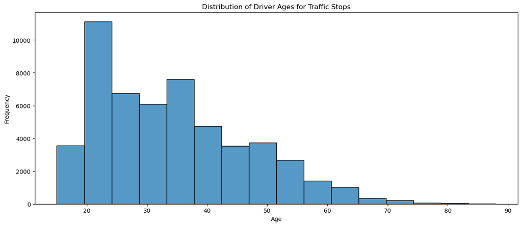

```python
plt.figure(figsize=(15, 6))
sns.histplot(df_new['driver_age'], bins=16)
plt.title('Distribution of Driver Ages for Traffic Stops')
plt.xlabel('Age')
plt.ylabel('Frequency')
plt.show()
```

What is the age range of the drivers? Is there a peak in certain age groups? How does the age distribution look for the entire dataset?

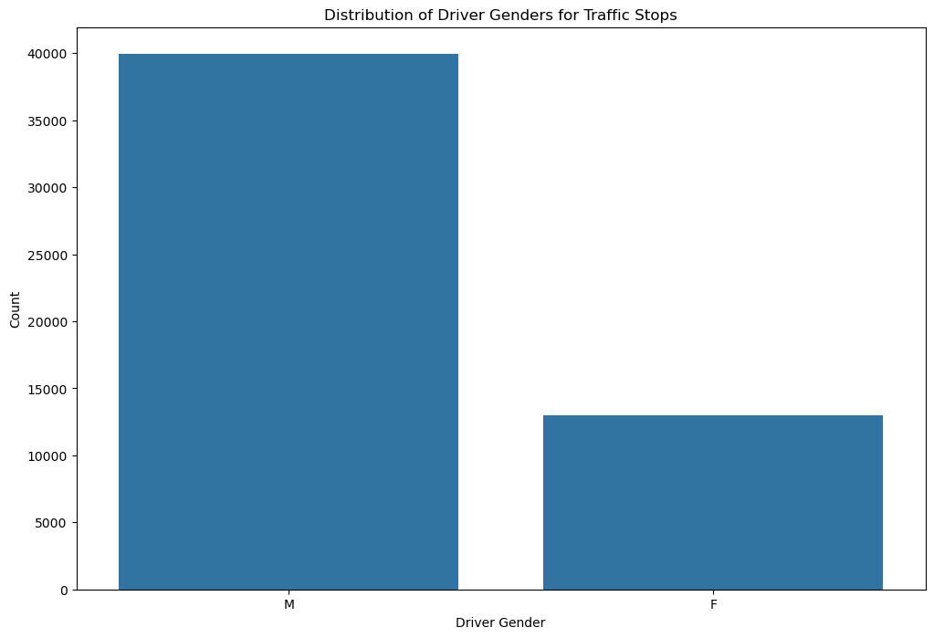

```python
plt.figure(figsize=(12, 8))
sns.countplot(x='driver_gender', data=df_new)
plt.title('Distribution of Driver Genders for Traffic Stops')
plt.xlabel('Driver Gender')
plt.ylabel('Count')
plt.show()
```

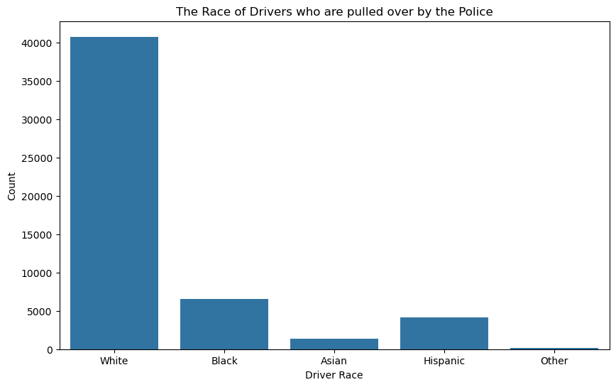

```python
plt.figure(figsize=(10, 6))
sns.countplot(x='driver_race', data=df_new)
plt.title('The Race of Drivers who are pulled over by the Police')
plt.xlabel('Driver Race')
plt.ylabel('Count')
plt.show()
```

What is the gender distribution of drivers?

- The gender distribution is heavily skweed towards males with over 75% of the dataset consisting of male drivers. Men are 3x more likely to get pulled over.

How does the race distribution compare between different genders?

Are there any surprising trends or imbalances in the demographics?

- A major imbalance is the signigicant number of male drivers and more specifically the number of white male drivers in this dataset. It causes room for potential bias or reporting mistakes. Also minority racial groups such as Black, Hispanic, and Asian drivers make up a relatively small portion of the data, which could refelct societal biases or location bias.

##### 2. Violation Types

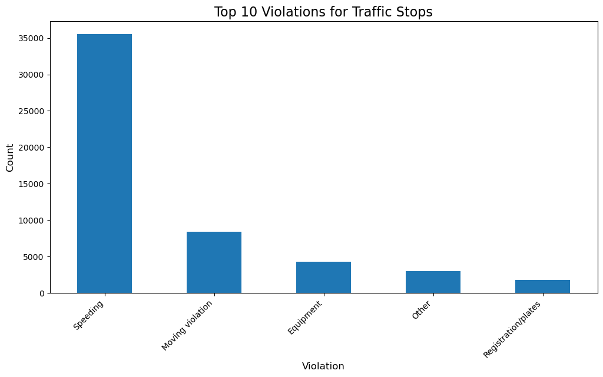

```python
top_violations = df_new['violation'].value_counts().head(10)
plt.figure(figsize=(12, 6))
top_violations.plot(kind='bar')
plt.title('Top 10 Violations for Traffic Stops', fontsize=16)
plt.xlabel('Violation', fontsize=12)
plt.ylabel('Count', fontsize=12)
plt.xticks(rotation=45, ha='right') #makes x-label readible
plt.show()
```

Questions:

What are the most common violations

Are there any patterns in the types of violation ? For example, do certain violations occur more frequently than other

- Speeding and Moviong violations are the highest cuase of traffic stops. Both these violations occur as a result of the drivers behavior. This suggests that driver behavior is a leading cause of traffic stops in this dataset. Violations related to equipment issues or registration/plates are less frequent and this suggest that law enforncement has this violation as low-risk or that this violtion is less frequent to occur. s?

#### 3. Search and Arrest Outcome

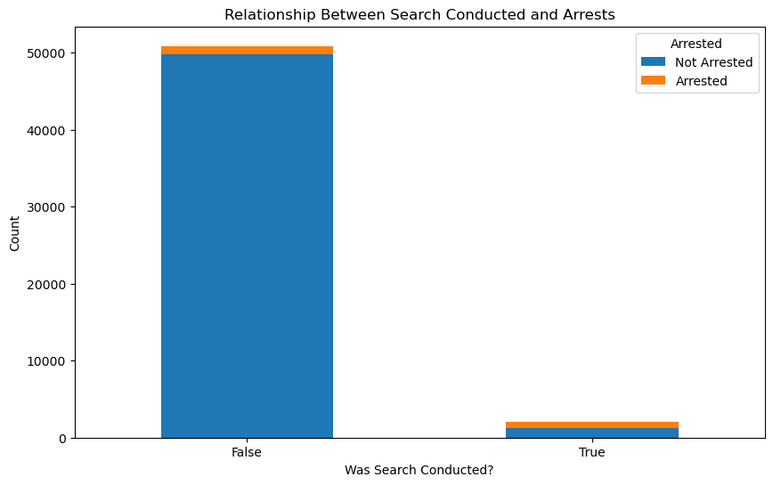

```python
#group the data with search_conducted and is_arrested
stacked_data = df_new.groupby(['search_conducted', 'is_arrested']).size().unstack()
#use function to plot stacked bar plot
stacked_data.plot(kind='bar', stacked=True, figsize=(10, 6))
#Set labels for plot and title
plt.title('Relationship Between Search Conducted and Arrests')
plt.xlabel('Was Search Conducted?')
plt.ylabel('Count')
#create legend to clarify color segments of plot
plt.legend(title='Arrested', labels= ['Not Arrested', 'Arrested'])
plt.xticks(rotation=0)
plt.show()
```

How does the search outcome affect the likelihood of arrest?

Is there a noticeable difference between searches that resulted in arrests versus those that didn’t?

- Out of about 2085 seaches, the arrest rate is relatively high whereas the majority of stops did not result in a seach and thus did not result in many arests in those situations.

Are searches more likely to lead to arrests for certain types of violations?

- Yes, drug and suspicous activity arrests typically require a search to be conducted and becuase a search conducted leads to a high probability of arrest, these specific violations are likely to lead to arrest.

##### 4. Hourly Trend of Traffic Stops

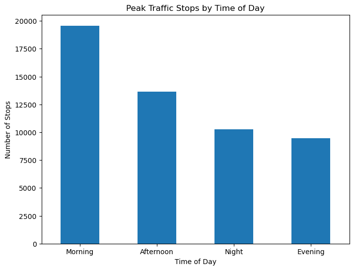

```python
#count number of stops that occur in each time of the day using value_counts
time_stops = df_new['time_of_day'].value_counts()
#size of plot figure
plt.figure(figsize=(8, 6))
#establishing what kind of plot
time_stops.plot(kind='bar')
plt.title('Peak Traffic Stops by Time of Day')
plt.xlabel('Time of Day')
plt.ylabel('Number of Stops')
plt.xticks(rotation=0)
plt.show()
```

Insights:

- Morning has the highest amount of traffic stops. This could be due to people rushing to work and/or driving half-awake. Also, a reason for such a peak in the morning could be due to which officers work morning shifts as well. Another factor could be data bias and this dataset had a pool of cases that were predominantly in the morning hours.

## 4. Analysis:

##### Investigate whether certain driver demographics (e.g., gender, race) are disproportionately associated with specific violations.s.

```python
# Create a cross-table of driver_gender and violation
gender_violation_crosstab = pd.crosstab(df_new['driver_gender'], df_new['violation'], margins=True, margins_name="Total")
# Display the table to analyze the correalation
print(gender_violation_crosstab)
```

```
violation      Equipment  Moving violation  Other  Registration/plates  \
driver_gender
F                    855              1390    354                  504
M                   3421              6995   2607                 1316
Total               4276              8385   2961                 1820

violation      Speeding  Total
driver_gender
F                  9913  13016
M                 25611  39950
Total             35524  52966
```

```python
# Calculate percentages for gender vs violation
gender_violation_percentage = pd.crosstab(df_new['driver_gender'], df_new['violation'], normalize='index') * 100
# Display the percentage table
print(gender_violation_percentage)
```

```
violation      Equipment  Moving violation     Other  Registration/plates  \
driver_gender
F               6.568838         10.679164  2.719730             3.872157
M               8.563204         17.509387  6.525657             3.294118

violation       Speeding
driver_gender
F              76.160111
M              64.107635
```

```python
race_violation_crosstab = pd.crosstab(df_new['driver_race'], df_new['violation'], margins=True, margins_name="Total")
# Display the table to analyze the correalation
print(race_violation_crosstab)
```

```
violation    Equipment  Moving violation  Other  Registration/plates  \
driver_race
Asian               92               162     62                   25
Black              857              1530    654                  428
Hispanic           652              1013    382                  358
Other                7                33     19                    1
White             2668              5647   1844                 1008
Total             4276              8385   2961                 1820

violation    Speeding  Total
driver_race
Asian            1034   1375
Black            3125   6594
Hispanic         1694   4099
Other              89    149
White           29582  40749
Total           35524  52966
```

*I added a percentage chart due to unbalanced distribution in data for males v females.*

##### Analyze the relationship between search_conducted and is_arrested.

```python
#First find the total numbers for each of these columns
print(df_new['search_conducted'].value_counts())
print(df_new['is_arrested'].value_counts())
```

```
search_conducted
False    50881
True      2085
Name: count, dtype: int64
is_arrested
False    51097
True      1869
Name: count, dtype: int64
```

```python
#Make a crosstable to analyze both these variables in a way that can be easily analyzed
arrest_table = pd.crosstab(df_new['search_conducted'], df_new['is_arrested'])
print(arrest_table)
```

```
is_arrested       False  True
search_conducted
False             49851   1030
True               1246    839
```

- There were over 52,000 stops in this dataset and only 2,085 where searches were conducted and only 1,869 where an arrest was made. There was only 839 cases where both an arrest and a search were conducted. This tells us that when a search is conducted during a traffic stop, the arrest rate is significantly higher (around 40.25%) compared to when no search is conducted (around 2.02%).

##### Examine the outcomes of traffic stops involving drugs-related violations.

```python
drug_stops = df_new['drugs_related_stop'].value_counts()
print(drug_stops)
```

```
drugs_related_stop
False    52570
True       396
Name: count, dtype: int64
```

```python
#comparing arrests and if those arrests were for drugs or not
comparison = pd.crosstab(df_new['drugs_related_stop'], df_new['is_arrested'])
print(comparison)
```

```
is_arrested         False  True
drugs_related_stop
False               50830   1740
True                  267    129
```

```python
#comparing drug related stops by the time of day
comparison_time = pd.crosstab(df_new['drugs_related_stop'], df_new['time_of_day'])
print(comparison_time)
```

```
time_of_day         Night  Morning  Afternoon  Evening
drugs_related_stop
False               10140    19520      13555     9355
True                  141       53         79      123
```

## Part 5: Expected Output

##### Question 1: Yearly Trend of Arrests

Investigate trends in arrests over the years.

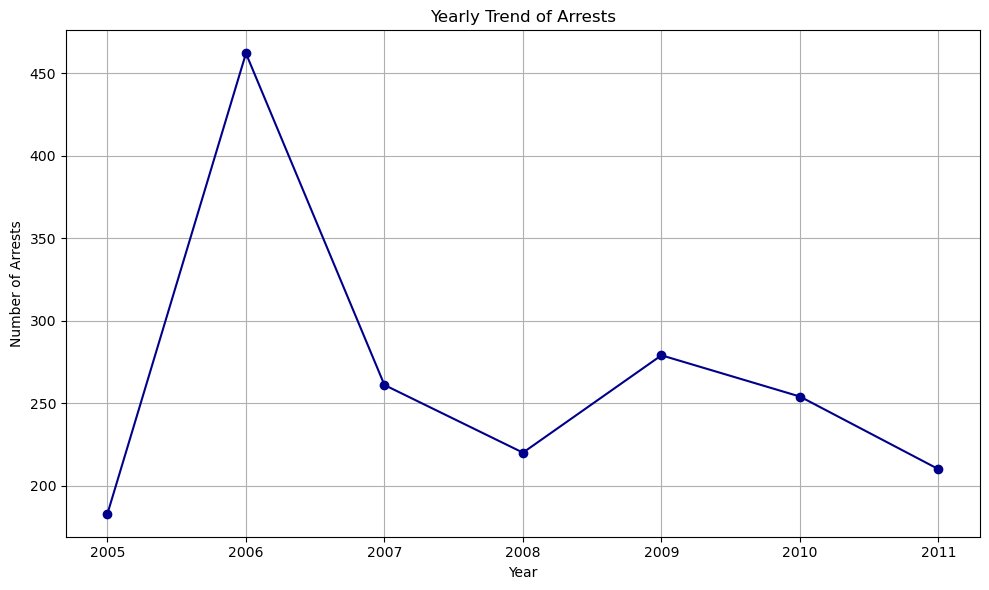

```python
#extract years from stop_date column
df_new['year'] = df_new['stop_date'].dt.year
#calculate arrests by year
arrest_year = df_new[df_new['is_arrested'] == True].groupby('year').size()
plt.figure(figsize=(10, 6))
arrest_year.plot(kind='line', marker= 'o', color='darkblue')
plt.title('Yearly Trend of Arrests')
plt.xlabel('Year')
plt.ylabel('Number of Arrests')
plt.grid()
plt.tight_layout()
plt.show()
```

##### Analysis

- There is a peak in arrests in the year 2006, reaching over 450 arrests. Between the years of 2005 and 2006, it would be helpful to understand what happened to increase the arrests. This could be due to increase awareness from law enforncement or the area this survey was done had increased crime.
- After 2006, there is decline in over 200 arrests and this trend stays rather constant with little fluctution for the next several years. This could likely be due to a decrease in reckless driving due to the drastic number of arrests in 2006.

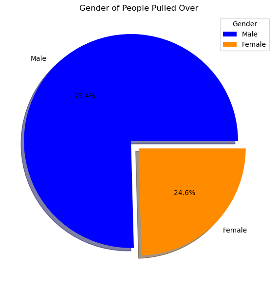

```python
gender_distribution = df_new['driver_gender'].value_counts(normalize=True)*100
plt.figure(figsize=(6, 6))
gender_distribution.plot(kind='pie', colors=['blue','darkorange'], labels=['Male', 'Female'], explode=(0.1,0), shadow=True, autopct='%1.1f%%')
plt.title('Gender of People Pulled Over')
plt.ylabel('')
plt.legend(title='Gender', labels= ['Male', 'Female'])
plt.tight_layout()
plt.show()
```

##### Anylsis:

- This pie chart showcases a comparison between genders in relation to traffic stops. Males make up over 75% of all cases for being pulled over in this dataset. This can showcase several assumptions. Statistically men are more likely to be reckless drivers or be more suspicous of criminal activity while driving. Also, this data could be means for bias in the dataset or an issue in collecting data.

## Part 6: Additional Analysis/Findings

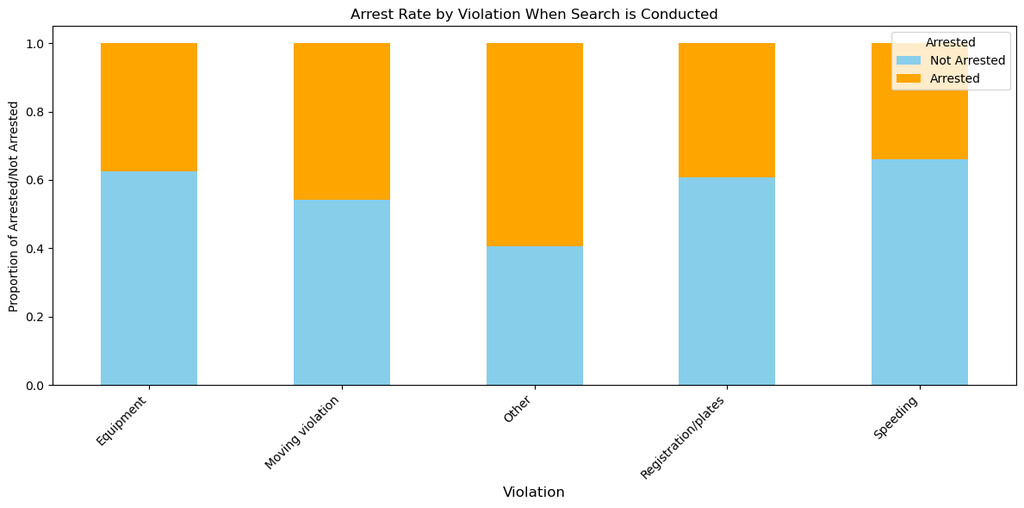

```python
# Group by violation and search_conducted, then calculate the arrest rate
search_arrest_data = df_new[df_new['search_conducted'] == True].groupby('violation')['is_arrested'].value_counts(normalize=True).unstack()
# Plot the arrest rate for each violation where searches were conducted
search_arrest_data.plot(kind='bar', stacked=True, figsize=(12, 6), color=['skyblue', 'orange'])
# Set plot labels and title
plt.title('Arrest Rate by Violation When Search is Conducted')
plt.xlabel('Violation', fontsize=12)
plt.ylabel('Proportion of Arrested/Not Arrested')
plt.legend(title='Arrested', labels=['Not Arrested', 'Arrested'])
plt.xticks(rotation=45, ha='right')
plt.tight_layout()
plt.show()
```

Steps & Findings:

- For this stacked bar graph, we grouped the data by the violation column and created a visualization that depicted the proportion of arrests and non-arrests "only" when there was a search conducted. This plot tells us that "other" has the highest proportion of arrests compared to other violations. Speeding has the least amount of arrests which makes sense as those violations typically result in a speeding ticket and a fine.

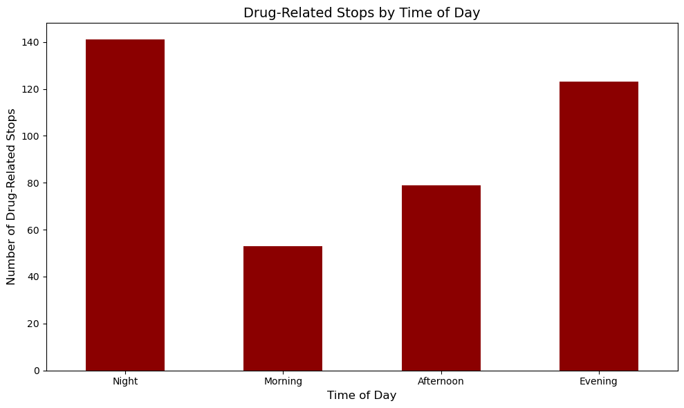

```python
# Filter so only True values for drugs_related_stop
#use comparison_time from row 84 in this notebook
true_drug_related_stops = comparison_time.loc[True]

# Plotting the bar chart
true_drug_related_stops.plot(kind='bar', figsize=(10, 6), color='darkred')

# Adding titles and labels
plt.title('Drug-Related Stops by Time of Day', fontsize=14)
plt.xlabel('Time of Day', fontsize=12)
plt.ylabel('Number of Drug-Related Stops', fontsize=12)
plt.xticks(rotation=0)
plt.tight_layout()

# Show plot
plt.show()
```

Analysis:

- The night is a time often associated with increased illegal activity or impaired driving and Law enforcement may target this period due to heightened suspicion of drug-related offenses. This allows us to conclude that the night patrol officers are favoring only stopping a vehicle if they suspect it of drugs. Stops drop sharply during the morning, which is typically a time associated with commuting to work or school. Also, law enforcement prioritize other traffic violations during this time of the day.

```python
df_new.to_csv('cleaned_traffic_violaions.csv')
```